# Car Prices

```r
library(tidyverse)
library(mosaic)
library(car)
library(DT)
library(pander)
```

## Background

For years, I have seen my grandparents drive around in their Buick Lacrosse’s; grandpa has a white one and grandma has a silver one. They insist that those cars last forever, and encourage me to buy one. Though they do not have me quite convinced, I am interested to see if there is a significant difference between each of the 3 trims with regards to their depreciation.

## Hypothesis

The mathematical model used in this analysis will be:

$$Y_i=\beta_0+\beta_1X_{i1}+\beta_2X_{i2}+\beta_3X_{i3}+\beta_4 X_{i1}X_{i2}+\beta_5X_{i1}X_{i3}+\epsilon_i$$
Where $\beta_0=\text{The average price of a Buick Lacrosse CX with 0 miles}$,

$\beta_1$$X_{i1}\text{(mileage of vehicle)}$=The effect of each mile on the average price,

$\beta_2$$X_{i2}\text{(1 if vehicle = CXL, 0 if vehicle}\neq\text{CXL)}$= How much more or less a CXL trim costs on average compared to a CX,

$\beta_3$$X_{i3}\text{(1 if vehicle = CXS, 0 if vehicle}\neq\text{CXS)}$= How much more or less a CXS trim costs on average compared to a CX,

$\beta_4 X_{i1}X_{i2}\text{(1 if vehicle = CXL, 0 if vehicle}\neq\text{CXL)}$= The interaction term between $X_{i1}$&$X_{i2}$, which allows for the change in slope between the baseline CX trim and the CXL trim,

$\beta_5X_{i1}X_{i3}\text{1 if vehicle = CXS, 0 if vehicle}\neq\text{CXS)}$= The interaction term between $X_{i1}$&$X_{i3}$, which allows for the change in slope between the baseline CX trim and the CXS trim.

## Data

The original “CarPrices” data set was filtered to only include the data for the Buick Lacrosse. There are three trims of the Lacrosse that are used in this study: CX, CXL, and CXS. All of which are four-door sedans. The following data table contains the filtered data that was used in the multiple linear regression test. The original data set also included other characteristics of each vehicle, but I have not included them in the table because they were not considered in the test. Each of the three trim styles have 10 data points, bringing the total to 30 for the test.

```r
CPBuick <- filter(CarPrices, Model == "Lacrosse")

CPBuick2 <- select (CPBuick, (Price), Mileage, Model, Trim)
datatable(CPBuick2, options=list(lengthMenu = c(5, 10, 30)), extensions = "Responsive")
```

|  | Price | Mileage | Model | Trim |
| --- | --- | --- | --- | --- |
| 1 | 21335.85248 | 10237 | Lacrosse | CX Sedan 4D |
| 2 | 20538.08751 | 15066 | Lacrosse | CX Sedan 4D |
| 3 | 20512.09409 | 16633 | Lacrosse | CX Sedan 4D |
| 4 | 19924.15905 | 19800 | Lacrosse | CX Sedan 4D |
| 5 | 19774.24907 | 23359 | Lacrosse | CX Sedan 4D |
| 6 | 19344.16554 | 23765 | Lacrosse | CX Sedan 4D |
| 7 | 19105.13012 | 24008 | Lacrosse | CX Sedan 4D |
| 8 | 18543.42705 | 26034 | Lacrosse | CX Sedan 4D |
| 9 | 17808.199 | 32896 | Lacrosse | CX Sedan 4D |
| 10 | 17968.83828 | 34665 | Lacrosse | CX Sedan 4D |

[output cut: 20 more lines]

## Analysis

The change in y-intercept was not considered, because in this analysis, it represents the initial price of the vehicle. This is not exactly an interesting topic, given that the starting prices for each vehicle will simply be whatever the dealership decides to sell it for.

#### Diagnostic Plots

The check if we can trust the results of our regression test, we examine these plots:

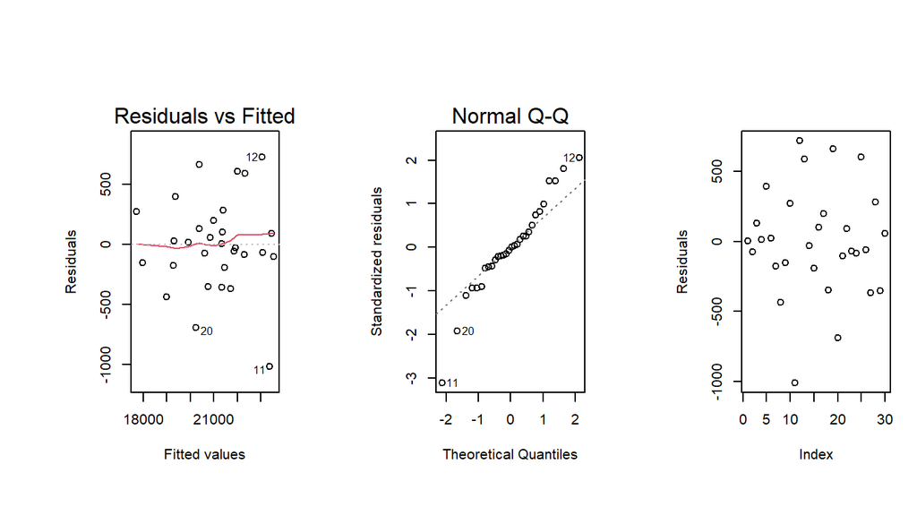

```r
Buick.lm <- lm(Price ~ Mileage + Trim + Mileage:Trim, data = CPBuick)

par(mfrow=c(1,3), mai=c(1,1,1,.2))
 plot(Buick.lm, which=1:2)
 plot(Buick.lm$residuals, ylab="Residuals")
```

Though there does appear to be a bit of a normality issue in the QQ-Plot, it is not enough to disregard the results of our test. The Residuals however appear to have a megaphone shape, which means that our requirements have not been met. The residuals vs index plot does seem to show us that our errors are independent of each other.

Regardless of our requirements not being fully met, I will still run the multiple regression test, just keeping in mind that we cannot trust our results:

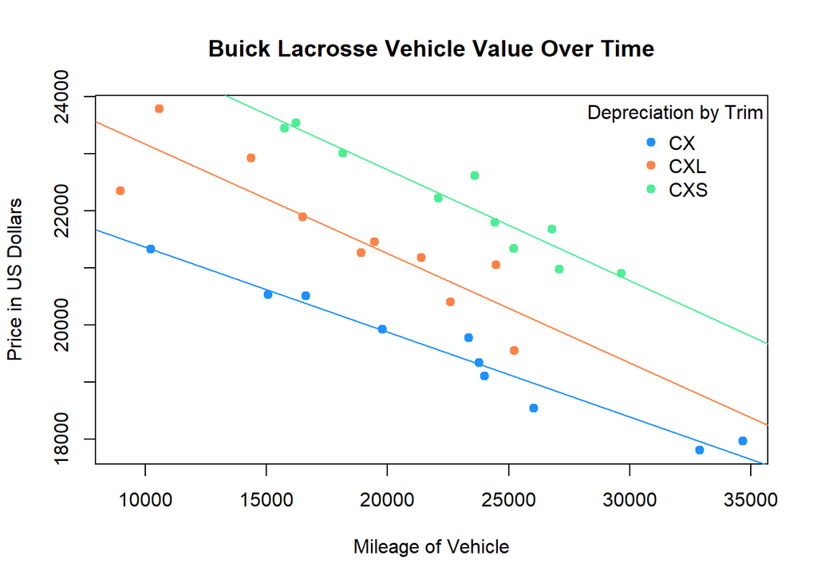

```r
palette(c("dodgerblue1","sienna1","seagreen2"))
plot(Price ~ Mileage, data = CPBuick, col = as.factor(Trim), pch = 19, xlab= "Mileage of Vehicle", ylab = "Price in US Dollars", main = "Buick Lacrosse Vehicle Value Over Time")
abline(22856, -.1488, col=palette()[1])
abline(25094, -.19194, col =palette()[2])
abline(26619, -.19474, col =palette()[3])
legend("topright", legend=c("CX","CXL", "CXS"), pch=19, col=palette(), title="Depreciation by Trim", bty="n")
```

The baseline trim was CX, given that it is the first of the three alphabetically. It also happens to be the line with the smallest y-intercept, making the graphical summary easier to interpret.The results of the test are as follows:

```r
summary(Buick.lm) %>%
  pander(caption = "Regression Summary of Depreciation Based on Trim")
```

|  | Estimate | Std. Error | t value | Pr(>\|t\|) |
| --- | --- | --- | --- | --- |
| **(Intercept)** | 22856 | 439.1 | 52.05 | 3.4e-26 |
| **Mileage** | -0.1488 | 0.01848 | -8.056 | 2.788e-08 |
| **TrimCXL Sedan 4D** | 2238 | 648.7 | 3.45 | 0.002084 |
| **TrimCXS Sedan 4D** | 3763 | 815.3 | 4.615 | 0.0001106 |
| **Mileage:TrimCXL Sedan 4D** | -0.04314 | 0.03118 | -1.384 | 0.1792 |
| **Mileage:TrimCXS Sedan 4D** | -0.04594 | 0.03474 | -1.322 | 0.1986 |

Regression Summary of Depreciation Based on Trim

| Observations | Residual Std. Error | $R^2$ | Adjusted $R^2$ |
| --- | --- | --- | --- |
| 30 | 421.4 | 0.9421 | 0.93 |

From these results we can create a model equation for the regression lines for each model:

$$\text{CX}:Y_i=22856-.1488X_i$$
$$\text{CXL}:Y_i=25094-.19194X_i$$
$$\text{CXS}:Y_i=26619-.19474X_i$$